# Introduction & Univariate analysis

[figure not shown]

## Interesting resources:

- Python Basics
  - https://courses.edx.org/courses/course-v1:IBM+PY0101EN+3T2020/course/ Module 1, 2 & 3
- DataFrame Basics
  - https://campus.datacamp.com/courses/introduction-to-data-science-in-python/loading-data-in-pandas?ex=1
  - https://campus.datacamp.com/courses/pandas-foundations/data-ingestion-inspection?ex=1
  - https://www.coursera.org/learn/python-data-analysis?specialization=data-science-python#syllabus
- Cheat sheets:
  - https://pydatascience.org/data-science-cheatsheets/

## Intro Python, Pandas and DataFrames

```python
import pandas as pd
```

```python
import seaborn as sns
```

```python
iris = sns.load_dataset("iris")
```

```python
iris
```

|  | sepal_length | sepal_width | petal_length | petal_width | species |
| --- | --- | --- | --- | --- | --- |
| 0 | 5.1 | 3.5 | 1.4 | 0.2 | setosa |
| 1 | 4.9 | 3.0 | 1.4 | 0.2 | setosa |
| 2 | 4.7 | 3.2 | 1.3 | 0.2 | setosa |
| 3 | 4.6 | 3.1 | 1.5 | 0.2 | setosa |
| 4 | 5.0 | 3.6 | 1.4 | 0.2 | setosa |
| ... | ... | ... | ... | ... | ... |
| 145 | 6.7 | 3.0 | 5.2 | 2.3 | virginica |
| 146 | 6.3 | 2.5 | 5.0 | 1.9 | virginica |
| 147 | 6.5 | 3.0 | 5.2 | 2.0 | virginica |
| 148 | 6.2 | 3.4 | 5.4 | 2.3 | virginica |
| 149 | 5.9 | 3.0 | 5.1 | 1.8 | virginica |

150 rows × 5 columns

```python
type(iris)
```

```
pandas.core.frame.DataFrame
```

```python
iris.head()
```

|  | sepal_length | sepal_width | petal_length | petal_width | species |
| --- | --- | --- | --- | --- | --- |
| 0 | 5.1 | 3.5 | 1.4 | 0.2 | setosa |
| 1 | 4.9 | 3.0 | 1.4 | 0.2 | setosa |
| 2 | 4.7 | 3.2 | 1.3 | 0.2 | setosa |
| 3 | 4.6 | 3.1 | 1.5 | 0.2 | setosa |
| 4 | 5.0 | 3.6 | 1.4 | 0.2 | setosa |

[figure not shown]

```python
iris.columns
```

```
Index(['sepal_length', 'sepal_width', 'petal_length', 'petal_width',
       'species'],
      dtype='object')
```

```python
iris.dtypes
```

```
sepal_length    float64
sepal_width     float64
petal_length    float64
petal_width     float64
species          object
dtype: object
```

```python
print(iris.shape)
print(len(iris))
print(len(iris.columns))
```

```
(150, 5)
150
5
```

```python
iris['sepal_length']
```

```
0      5.1
1      4.9
2      4.7
3      4.6
4      5.0
      ...
145    6.7
146    6.3
147    6.5
148    6.2
149    5.9
Name: sepal_length, Length: 150, dtype: float64
```

```python
type(iris['sepal_length'])
```

```
pandas.core.series.Series
```

```python
iris[['sepal_length','sepal_width']]
```

|  | sepal_length | sepal_width |
| --- | --- | --- |
| 0 | 5.1 | 3.5 |
| 1 | 4.9 | 3.0 |
| 2 | 4.7 | 3.2 |
| 3 | 4.6 | 3.1 |
| 4 | 5.0 | 3.6 |
| ... | ... | ... |
| 145 | 6.7 | 3.0 |
| 146 | 6.3 | 2.5 |
| 147 | 6.5 | 3.0 |
| 148 | 6.2 | 3.4 |
| 149 | 5.9 | 3.0 |

150 rows × 2 columns

```python
columns = ['sepal_length','sepal_width']
iris[columns]
```

|  | sepal_length | sepal_width |
| --- | --- | --- |
| 0 | 5.1 | 3.5 |
| 1 | 4.9 | 3.0 |
| 2 | 4.7 | 3.2 |
| 3 | 4.6 | 3.1 |
| 4 | 5.0 | 3.6 |
| ... | ... | ... |
| 145 | 6.7 | 3.0 |
| 146 | 6.3 | 2.5 |
| 147 | 6.5 | 3.0 |
| 148 | 6.2 | 3.4 |
| 149 | 5.9 | 3.0 |

150 rows × 2 columns

```python
type(columns)
```

```
list
```

```python
iris.loc[0:4] # inclusive! 0:4 are treated as labels, not indices!
```

|  | sepal_length | sepal_width | petal_length | petal_width | species |
| --- | --- | --- | --- | --- | --- |
| 0 | 5.1 | 3.5 | 1.4 | 0.2 | setosa |
| 1 | 4.9 | 3.0 | 1.4 | 0.2 | setosa |
| 2 | 4.7 | 3.2 | 1.3 | 0.2 | setosa |
| 3 | 4.6 | 3.1 | 1.5 | 0.2 | setosa |
| 4 | 5.0 | 3.6 | 1.4 | 0.2 | setosa |

[Good explanation about pandas](https://medium.com/dunder-data/selecting-subsets-of-data-in-pandas-6fcd0170be9c)

```python
iris.loc[0:4, columns]
```

|  | sepal_length | sepal_width |
| --- | --- | --- |
| 0 | 5.1 | 3.5 |
| 1 | 4.9 | 3.0 |
| 2 | 4.7 | 3.2 |
| 3 | 4.6 | 3.1 |
| 4 | 5.0 | 3.6 |

```python
versicolorFilter = iris['species'] == 'versicolor'
iris[versicolorFilter].head()
```

|  | sepal_length | sepal_width | petal_length | petal_width | species |
| --- | --- | --- | --- | --- | --- |
| 50 | 7.0 | 3.2 | 4.7 | 1.4 | versicolor |
| 51 | 6.4 | 3.2 | 4.5 | 1.5 | versicolor |
| 52 | 6.9 | 3.1 | 4.9 | 1.5 | versicolor |
| 53 | 5.5 | 2.3 | 4.0 | 1.3 | versicolor |
| 54 | 6.5 | 2.8 | 4.6 | 1.5 | versicolor |

## Univariate analysis

Unvariate: Look at 1 column at a time.  
The type of univariate analysis that can be performed depends on the type of data the column has.

[figure not shown]

### Univariate analysis: Categorical data

Discrete values. Like enums.

```python
iris['species']
```

```
0         setosa
1         setosa
2         setosa
3         setosa
4         setosa
         ...
145    virginica
146    virginica
147    virginica
148    virginica
149    virginica
Name: species, Length: 150, dtype: object
```

```python
iris['species'].unique()
```

```
array(['setosa', 'versicolor', 'virginica'], dtype=object)
```

```python
iris['species'].value_counts()
```

```
setosa        50
versicolor    50
virginica     50
Name: species, dtype: int64
```

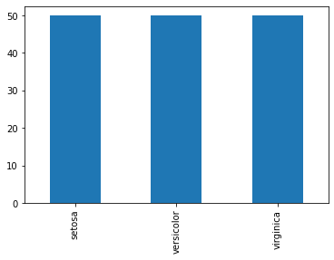

```python
iris['species'].value_counts().plot(kind='bar')
```

### Portfolio assignment 3

15 min: Perform a univariate analysis on all the categorical data of the penguins dataset. Commit the notebook to your portfolio when you're finished. Optional: Start working on portfolio assignment 4

[figure not shown]

```python
penguins = sns.load_dataset("penguins")
```

```python
penguins.head()
```

|  | species | island | bill_length_mm | bill_depth_mm | flipper_length_mm | body_mass_g | sex |
| --- | --- | --- | --- | --- | --- | --- | --- |
| 0 | Adelie | Torgersen | 39.1 | 18.7 | 181.0 | 3750.0 | Male |
| 1 | Adelie | Torgersen | 39.5 | 17.4 | 186.0 | 3800.0 | Female |
| 2 | Adelie | Torgersen | 40.3 | 18.0 | 195.0 | 3250.0 | Female |
| 3 | Adelie | Torgersen | NaN | NaN | NaN | NaN | NaN |
| 4 | Adelie | Torgersen | 36.7 | 19.3 | 193.0 | 3450.0 | Female |

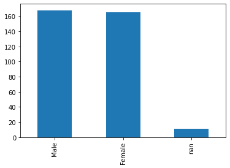

```python
penguins['sex'].value_counts(dropna=False).plot(kind='bar')
```

#### List unique categorical data values

```python
penguins['species'].unique()
```

```
array(['Adelie', 'Chinstrap', 'Gentoo'], dtype=object)
```

```python
penguins['island'].unique()
```

```
array(['Torgersen', 'Biscoe', 'Dream'], dtype=object)
```

```python
penguins['sex'].unique()
```

```
array(['Male', 'Female', nan], dtype=object)
```

#### Count categorical data

```python
penguins['species'].value_counts()
```

```
Adelie       152
Gentoo       124
Chinstrap     68
Name: species, dtype: int64
```

```python
penguins['island'].value_counts()
```

```
Biscoe       168
Dream        124
Torgersen     52
Name: island, dtype: int64
```

```python
penguins['sex'].value_counts()
```

```
Male      168
Female    165
Name: sex, dtype: int64
```

#### Plot categorical data

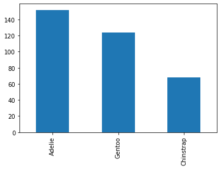

```python
penguins['species'].value_counts().plot(kind='bar')
```

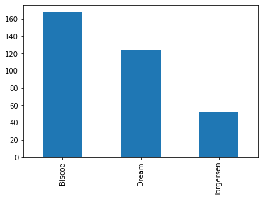

```python
penguins['island'].value_counts().plot(kind='bar')
```

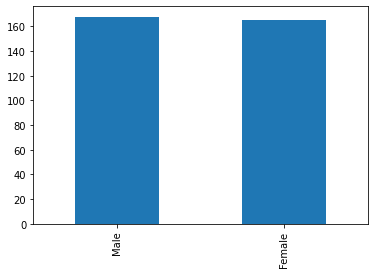

```python
penguins['sex'].value_counts().plot(kind='bar')
```

### Portfolio assignment 4

15 min: Look online for a datset that you personally find interesting to explore. It can be about any topic that you find interesting: sports, games, software development, etc. Commit the dataset to your portfolio. You will be analysing the dataset in future portfolio assignments.

Required characteristics of the dataset:

- Must be in a tabular format: Contains rows and columns
- Contains at least 100 rows
- Contains at least 2 columns with categorical data and at least 2 columns with numerical data
- Is less than 200 MB

[figure not shown]

### Univariate analysis: Numerical data

```python
column = 'sepal_length'
iris[column].min()
```

```
4.3
```

```python
iris[column].max()
```

```
7.9
```

```python
iris[column].mean()
```

```
5.843333333333334
```

[figure not shown]

```python
iris[column].median()
```

```
5.8
```

[figure not shown]

```python
example_column1 = pd.Series([1,2,3,4, 1000])
```

```python
print(example_column1.mean())
print(example_column1.median())
```

```
202.0
3.0
```

```python
iris[column].std()
```

```
0.828066127977863
```

[figure not shown]

```python
example_column1.std()
```

```
446.0969625541066
```

```python
(((example_column1 - example_column1.mean())**2).sum() / ( len(example_column1)-1))**0.5
```

```
446.0969625541066
```

```python
example_column2 = pd.Series([1,1,1,1,1,1])
example_column3 = pd.Series([1,2,3,4,5,6])
example_column4 = pd.Series([1,2,3,4,5,100])
example_column5 = pd.Series([10,20,30,40,50,60])
```

```python
(example_column2.std(), example_column3.std(), example_column4.std(), example_column5.std())
```

```
(0.0, 1.8708286933869707, 39.62532860010963, 18.708286933869708)
```

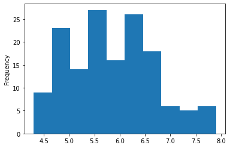

```python
iris[column].plot(kind='hist', bins = 10)
```

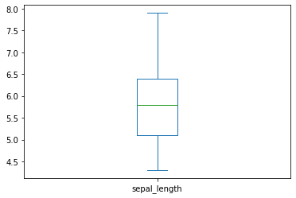

```python
iris[column].plot(kind='box')
```

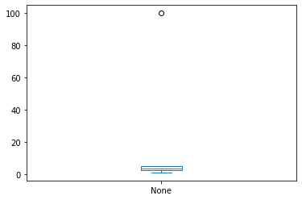

```python
example_column4.plot(kind='box')
```

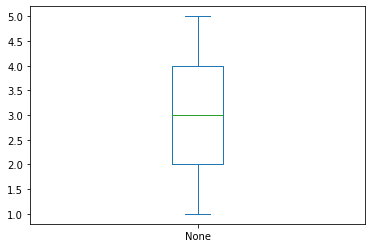

```python
# remove the outlier
example_column4[example_column4 < 10].plot(kind='box')
```

[figure not shown]

### Portfolio assignment 5

20 min:

- Download lifeExpectancyAtBirth.csv from Brightspace ([original source](https://www.kaggle.com/utkarshxy/who-worldhealth-statistics-2020-complete?select=lifeExpectancyAtBirth.csv)).
- Move the file to the same folder as the Notebook that you will be working in.
- Load the dataset in your Notebook with the following code: lifeExpectancy = pd.read_csv('lifeExpectancyAtBirth.csv', sep=',')
- Look at the dataset with the .head() function.
- Filter the dataframe: We only want the life expectancy data about 2019 and 'Both sexes'
- Use this dataframe to perform a univariate analysis on the life expectancy in 2019.
- Which five countries have the highest life expectancy? Which five the lowest?

Commit the notebook and dataset to your portfolio when you're finished.

[figure not shown]

```python
leab = pd.read_csv('lifeExpectancyAtBirth.csv', sep=',')
```

```python
leab = leab[leab.eval('Period == 2019 & Dim1 == \'Both sexes\'')]
leab.head()

lifeExpectancy = 'First Tooltip'
```

```python
print(f'median: {leab[lifeExpectancy].median()}')
print(f'mean: {leab[lifeExpectancy].mean()}')
print(f'standard deviation: {leab[lifeExpectancy].std()}')
```

```
median: 73.74
mean: 72.54049180327868
standard deviation: 7.129956404370867
```

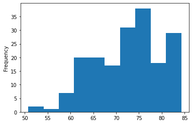

```python
leab[lifeExpectancy].plot(kind='hist')
```

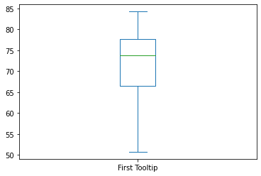

```python
leab[lifeExpectancy].plot(kind='box')
```

```python
leab.sort_values(lifeExpectancy).head(5)
```

|  | Location | Period | Indicator | Dim1 | First Tooltip |
| --- | --- | --- | --- | --- | --- |
| 1117 | Lesotho | 2019 | Life expectancy at birth (years) | Both sexes | 50.75 |
| 373 | Central African Republic | 2019 | Life expectancy at birth (years) | Both sexes | 53.10 |
| 1801 | Somalia | 2019 | Life expectancy at birth (years) | Both sexes | 56.47 |
| 661 | Eswatini | 2019 | Life expectancy at birth (years) | Both sexes | 57.73 |
| 1333 | Mozambique | 2019 | Life expectancy at birth (years) | Both sexes | 58.14 |

```python
leab.sort_values(lifeExpectancy).tail(5).iloc[::-1]
```

|  | Location | Period | Indicator | Dim1 | First Tooltip |
| --- | --- | --- | --- | --- | --- |
| 997 | Japan | 2019 | Life expectancy at birth (years) | Both sexes | 84.26 |
| 1897 | Switzerland | 2019 | Life expectancy at birth (years) | Both sexes | 83.45 |
| 1573 | Republic of Korea | 2019 | Life expectancy at birth (years) | Both sexes | 83.30 |
| 1753 | Singapore | 2019 | Life expectancy at birth (years) | Both sexes | 83.22 |
| 1837 | Spain | 2019 | Life expectancy at birth (years) | Both sexes | 83.22 |

### Portfolio assignment 6

60 min: Perform a univariate analysis on at least 2 columns with categorical data and on at least 2 columns with numerical data in the dataset that you chose in portfolio assignment 4. Commit the Notebook to your portfolio when you're finished.

[figure not shown]

```python
satcat = pd.read_csv('..\satcat-dec-2020\satcat-latest.csv', ',')
satcat.head()
```

|  | OBJECT_NAME | OBJECT_ID | NORAD_CAT_ID | OBJECT_TYPE | OPS_STATUS_CODE | OWNER | LAUNCH_DATE | LAUNCH_SITE | DECAY_DATE | PERIOD | INCLINATION | APOGEE | PERIGEE | RCS | DATA_STATUS_CODE | ORBIT_CENTER | ORBIT_TYPE |
| --- | --- | --- | --- | --- | --- | --- | --- | --- | --- | --- | --- | --- | --- | --- | --- | --- | --- |
| 0 | SL-1 R/B | 1957-001A | 1 | R/B | D | CIS | 1957-10-04 | TYMSC | 1957-12-01 | 96.19 | 65.10 | 938.0 | 214.0 | 20.420 | NaN | EA | IMP |
| 1 | SPUTNIK 1 | 1957-001B | 2 | PAY | D | CIS | 1957-10-04 | TYMSC | 1958-01-03 | 96.10 | 65.00 | 1080.0 | 64.0 | NaN | NaN | EA | IMP |
| 2 | SPUTNIK 2 | 1957-002A | 3 | PAY | D | CIS | 1957-11-03 | TYMSC | 1958-04-14 | 103.74 | 65.33 | 1659.0 | 211.0 | 0.080 | NaN | EA | IMP |
| 3 | EXPLORER 1 | 1958-001A | 4 | PAY | D | US | 1958-02-01 | AFETR | 1970-03-31 | 88.48 | 33.15 | 215.0 | 183.0 | NaN | NaN | EA | IMP |
| 4 | VANGUARD 1 | 1958-002B | 5 | PAY | NaN | US | 1958-03-17 | AFETR | NaN | 132.74 | 34.25 | 3833.0 | 650.0 | 0.122 | NaN | EA | ORB |

#### Categorical univariate analysis

univariate analysis of the collumns OBJECT_TYPE and OWNER

```python
print(f'OBJECT_TYPE\nunique values:\n{satcat["OBJECT_TYPE"].unique()}\nvalue counts:\n{satcat["OBJECT_TYPE"].value_counts()}')
print('\n')
print(f'OWNER\nunique values:\n{satcat["OWNER"].unique()}\nvalue counts:\n{satcat["OWNER"].value_counts()}')
```

```
OBJECT_TYPE
unique values:
['R/B' 'PAY' 'DEB' 'UNK']
value counts:
DEB    30923
PAY    10069
R/B     6181
UNK       59
Name: OBJECT_TYPE, dtype: int64


OWNER
unique values:
['CIS' 'US' 'UK' 'CA' 'IT' 'ITSO' 'FR' 'AUS' 'ESRO' 'GER' 'JPN' 'NATO'
 'PRC' 'NETH' 'SPN' 'FGER' 'IND' 'ESA' 'INDO' 'CZCH' 'EUTE' 'ARGN' 'AB'
 'BRAZ' 'MEX' 'SWED' 'RP' 'ISRA' 'SES' 'AC' 'PAKI' 'NOR' 'IM' 'ORB' 'SKOR'
 'GREC' 'POR' 'EUME' 'THAI' 'TURK' 'UKR' 'MALA' 'ABS' 'GLOB' 'EGYP' 'CHLE'
 'STCT' 'ISS' 'ROC' 'DEN' 'SAFR' 'SEAL' 'CHBZ' 'SAUD' 'UAE' 'NICO' 'ALG'
 'NIG' 'USBZ' 'IRAN' 'KAZ' 'COL' 'RASC' 'VTNM' 'VENZ' 'SWTZ' 'SING' 'LUXE'
 'ROM' 'HUN' 'POL' 'BELA' 'NKOR' 'AZER' 'ASRA' 'ECU' 'EST' 'O3B' 'PERU'
 'BOL' 'FRIT' 'LTU' 'BEL' 'URY' 'IRAQ' 'TMMC' 'LAOS' 'SGJP' 'FIN' 'BUL'
 'GHA' 'MNG' 'BGD' 'TBD' 'MA' 'ANG' 'NZ' 'KEN' 'CRI' 'BHUT' 'JOR' 'GRSA'
 'SRI' 'NEP' 'SDN' 'RWA' 'GUAT' 'SVN']
value counts:
CIS     22569
US      14323
PRC      5719
FR       1325
JPN       703
        ...
GHA         1
ROM         1
URY         1
IRAQ        1
NICO        1
Name: OWNER, Length: 108, dtype: int64
```

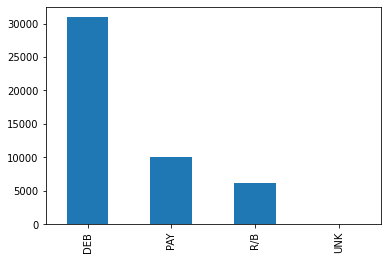

```python
satcat['OBJECT_TYPE'].value_counts().plot(kind='bar')
```

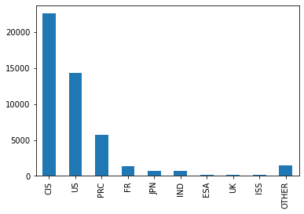

```python
ownerC = satcat['OWNER'].value_counts()
threshold = 100
mask = ownerC > threshold
tailC = ownerC.loc[~mask].sum()
ownerC = ownerC.loc[mask]
ownerC['OTHER'] = tailC
ownerC.plot(kind='bar')
```

#### Numerical univariate analysis

univariate analysis of the collums PERIOD and APOGEE

```python
satcat[['PERIOD', 'APOGEE']].describe()
```

|  | PERIOD | APOGEE |
| --- | --- | --- |
| count | 46385.000000 | 46385.000000 |
| mean | 197.715268 | 4309.597973 |
| std | 778.616633 | 15441.083052 |
| min | 79.650000 | 46.000000 |
| 25% | 89.220000 | 268.000000 |
| 50% | 94.410000 | 537.000000 |
| 75% | 103.270000 | 1008.000000 |
| max | 95687.680000 | 746743.000000 |

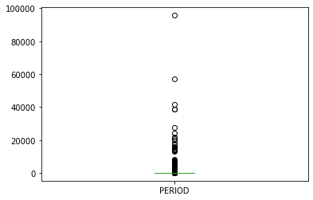

```python
satcat['PERIOD'].plot(kind='box')
```

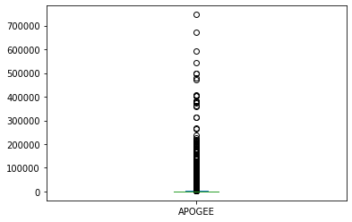

```python
satcat['APOGEE'].plot(kind='box')
```

##### Apogee scatter over period

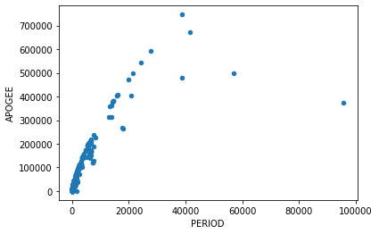

```python
satcat.plot(kind='scatter', x='PERIOD', y='APOGEE')
```